# 6. Discretized Non-negative Tensor Factorization (`dNTF`)

Koki Tsuyuzaki

Laboratory for Bioinformatics Research, RIKEN Center for Biosystems Dynamics Research  
k.t.the-answer@hotmail.co.jp

2023-03-07

# Introduction

In this vignette, we consider approximating a non-negative tensor as a product of binary or non-negative low-rank matrices (a.k.a., factor matrices).

Test data is available from `toyModel`.

```r
library("dcTensor")
X <- dcTensor::toyModel("dNTF")
```

You will see that there are four blocks in the data tensor as follows.

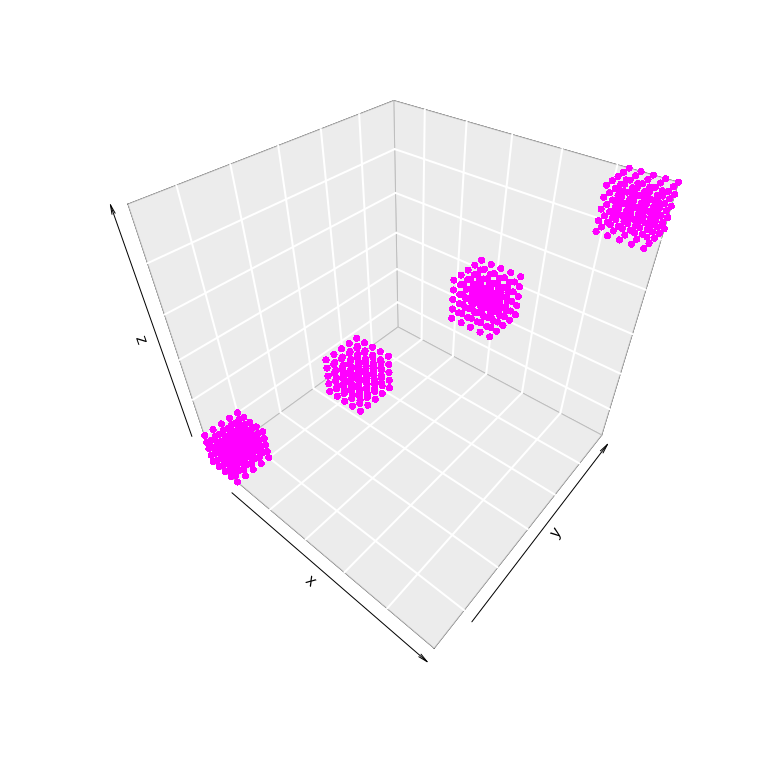

```r
suppressMessages(library("nnTensor"))
plotTensor3D(X)
```

# Binary Tensor Factorization (BTF)

To decompose a binary tensor ($\mathcal{X}$), non-negative CP decomposition (a.k.a. non-negative tensor factorization; NTF (Cichocki 2007; CICHOCK 2009)) can be applied. NTF appoximates $\mathcal{X}$ ($N \times M \times L$) as the mode-product of a core tensor $S$ ($J \times J \times J$) and factor matrices $A_1$ ($J \times N$), $A_2$ ($J \times M$), and $A_3$ ($J \times L$).

$$\mathcal{X} \approx \mathcal{S} \times_{1} A_1 \times_{2} A_2 \times_{3}
A_3\ \mathrm{s.t.}\ \mathcal{S} \geq 0, A_{k} \geq 0\ (k=1 \ldots 3)$$

## Basic Usage

In BTF, a rank parameter $J$ ($\leq \min(N, M)$) is needed to be set in advance. Other settings such as the number of iterations (`num.iter`) or factorization algorithm (`algorithm`) are also available. For the details of arguments of dNTF, see `?dNTF`. After the calculation, various objects are returned by `dNTF`. BTF is achieved by specifying the binary regularization parameter as a large value like the below:

```r
set.seed(123456)
out_dNTF <- dNTF(X, Bin_A=c(1e+2, 1e+2, 1e+2), algorithm="KL", rank=4)
str(out_dNTF, 2)
```

```
## List of 6
##  $ S            : num [1:4] 2.24 2.23 2.24 2.24
##  $ A            :List of 3
##   ..$ : num [1:4, 1:30] 9.99e-01 2.22e-16 2.22e-16 1.00 9.99e-01 ...
##   ..$ : num [1:4, 1:30] 1.00 2.22e-16 2.22e-16 2.22e-16 1.00 ...
##   ..$ : num [1:4, 1:30] 4.47e-01 9.94e-17 9.93e-17 9.93e-17 4.47e-01 ...
##  $ RecError     : Named num [1:28] 1.00e-09 2.67e+01 2.45e+01 2.36e+01 2.27e+01 ...
##   ..- attr(*, "names")= chr [1:28] "offset" "1" "2" "3" ...
##  $ TrainRecError: Named num [1:28] 1.00e-09 2.67e+01 2.45e+01 2.36e+01 2.27e+01 ...
##   ..- attr(*, "names")= chr [1:28] "offset" "1" "2" "3" ...
##  $ TestRecError : Named num [1:28] 1e-09 0e+00 0e+00 0e+00 0e+00 0e+00 0e+00 0e+00 0e+00 0e+00 ...
##   ..- attr(*, "names")= chr [1:28] "offset" "1" "2" "3" ...
##  $ RelChange    : Named num [1:28] 1.00e-09 2.56e-02 8.80e-02 4.16e-02 3.89e-02 ...
##   ..- attr(*, "names")= chr [1:28] "offset" "1" "2" "3" ...
```

The reconstruction error (`RecError`) and relative error (`RelChange`, the amount of change from the reconstruction error in the previous step) can be used to diagnose whether the calculation is converged or not.

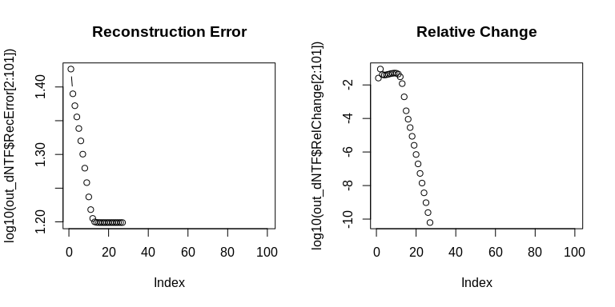

```r
layout(t(1:2))
plot(log10(out_dNTF$RecError[2:101]), type="b", main="Reconstruction Error")
plot(log10(out_dNTF$RelChange[2:101]), type="b", main="Relative Change")
```

The product of core tensor $S$ and factor matrices $A_{k}$ shows whether the original data is well-recovered by `dNTF`.

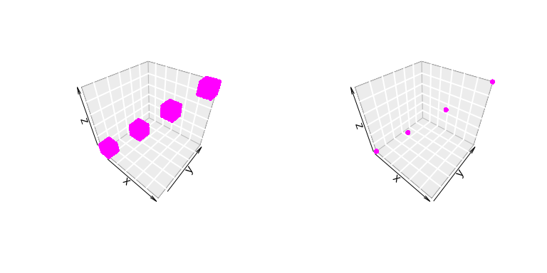

```r
recX <- recTensor(out_dNTF$S, out_dNTF$A)
layout(t(1:2))
plotTensor3D(X)
plotTensor3D(recX, thr=0)
```

The histograms of $A_{k}$s show that all the factor matrices $A_{k}$ looks binary.

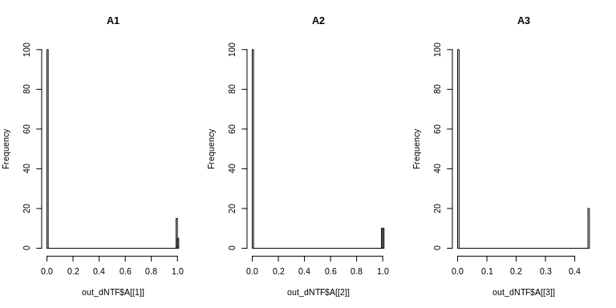

```r
layout(t(1:3))
hist(out_dNTF$A[[1]], main="A1", breaks=100)
hist(out_dNTF$A[[2]], main="A2", breaks=100)
hist(out_dNTF$A[[3]], main="A3", breaks=100)
```

# Semi-Binary Tensor Factorization (SBTF)

Here, we define this formalization as semi-binary tensor factorization (SBTF). SBTF can capture discrete patterns from non-negative matrices.

To demonstrate SBMF, next we use a non-negative tensor from the `nnTensor` package. You will see that there are four blocks in the data tensor as follows.

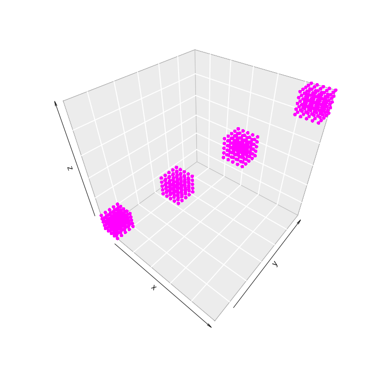

```r
X2 <- nnTensor::toyModel("CP")
plotTensor3D(X2)
```

## Basic Usage

In SBTF, a rank parameter $J$ ($\leq \min(N, M)$) is needed to be set in advance. Other settings such as the number of iterations (`num.iter`) or factorization algorithm (`algorithm`) are also available. For the details of arguments of dNTF, see `?dNTF`. After the calculation, various objects are returned by `dNTF`. SBTF is achieved by specifying the binary regularization parameter as a large value like the below:

```r
set.seed(123456)
out_dNTF2 <- dNTF(X2, Bin_A=c(1e+5, 1e+5, 1e-10), algorithm="KL", rank=4)
str(out_dNTF2, 2)
```

```
## List of 6
##  $ S            : num [1:4] 13.1 31.7 112.1 1474.1
##  $ A            :List of 3
##   ..$ : num [1:4, 1:30] 0.00704 0.00175 0.47548 0.00303 0.00653 ...
##   ..$ : num [1:4, 1:30] 0.00905 0.00602 0.10119 0.00226 0.0092 ...
##   ..$ : num [1:4, 1:30] 0.1385 0.2206 0.0447 0.0048 0.1523 ...
##  $ RecError     : Named num [1:101] 1.00e-09 2.46e+04 3.90e+03 2.96e+03 6.38e+03 ...
##   ..- attr(*, "names")= chr [1:101] "offset" "1" "2" "3" ...
##  $ TrainRecError: Named num [1:101] 1.00e-09 2.46e+04 3.90e+03 2.96e+03 6.38e+03 ...
##   ..- attr(*, "names")= chr [1:101] "offset" "1" "2" "3" ...
##  $ TestRecError : Named num [1:101] 1e-09 0e+00 0e+00 0e+00 0e+00 0e+00 0e+00 0e+00 0e+00 0e+00 ...
##   ..- attr(*, "names")= chr [1:101] "offset" "1" "2" "3" ...
##  $ RelChange    : Named num [1:101] 1.00e-09 8.23e-01 5.30 3.19e-01 5.36e-01 ...
##   ..- attr(*, "names")= chr [1:101] "offset" "1" "2" "3" ...
```

`RecError` and `RelChange` can be used to diagnose whether the calculation is converged or not.

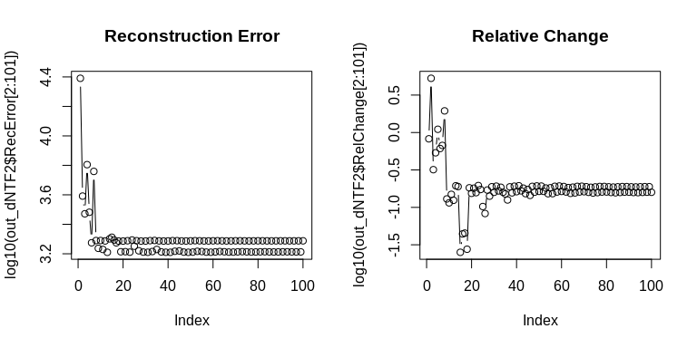

```r
layout(t(1:2))
plot(log10(out_dNTF2$RecError[2:101]), type="b", main="Reconstruction Error")
plot(log10(out_dNTF2$RelChange[2:101]), type="b", main="Relative Change")
```

The product of core tensor $S$ and factor matrices $A_{k}$ shows whether the original data is well-recovered by `dNTF`.

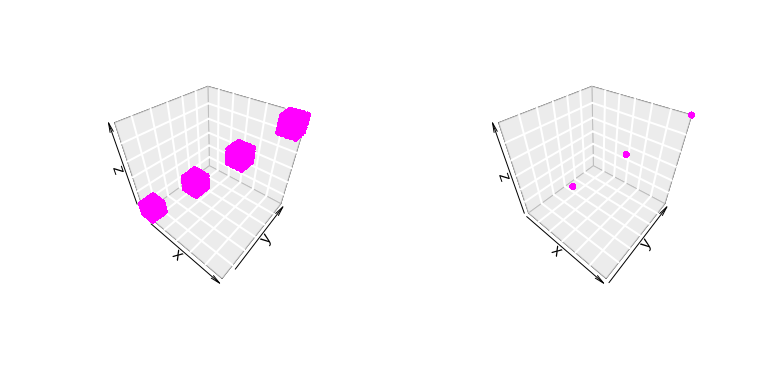

```r
recX <- recTensor(out_dNTF2$S, out_dNTF2$A)
layout(t(1:2))
plotTensor3D(X2)
plotTensor3D(recX, thr=0)
```

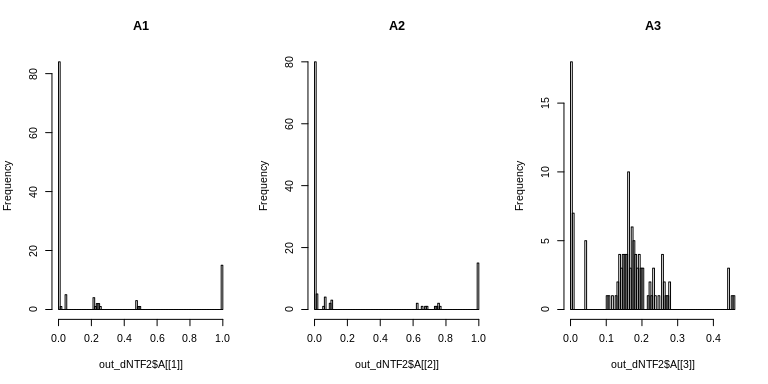

```r
layout(t(1:3))
hist(out_dNTF2$A[[1]], main="A1", breaks=100)
hist(out_dNTF2$A[[2]], main="A2", breaks=100)
hist(out_dNTF2$A[[3]], main="A3", breaks=100)
```

# References

CICHOCK, A. et al. 2009. *Nonnegative Matrix and Tensor Factorizations*. Wiley.

Cichocki, A. et al. 2007. “Non-Negative Tensor Factorization Using Alpha and Beta Divergence.” *ICASSP ’07*, III-1393-III-1396.